# EE5934 Deep Learning Project 1

In this project, you are going to explore Deep Learning and Neural Networks by completing the following three tasks:

- Task 1. Network Exploration (30%)
- Task 2. Model Interpretation (30%)
- Task 3. Adversarial Attack (40%)

Before doing the project, please read the instructions carefully (failure to do so will be penalized):

1. Implement your codes **within** "TODO" and "END OF YOUR CODE", do **NOT** modify any codes outside the answer area;
2. Make sure your codes **clean**, **easily readable** (add meaningful comments if needed), and **runnable**;
3. Write your answers in the given markdown cells, keep your answers clear and concise;
4. Do submit your project to "Files/Project 1/Submissions" on [LumiNUS](https://luminus.nus.edu.sg/) before the deadline: **5:59 pm (SGT), 6 March, 2022**;
5. This is an individual project, do **NOT** share your solutions with others, we have zero tolerance for cheating.

If you have any questions regarding this project, please feel free to contact Wu Zhangjie (zhangjiewu@u.nus.edu).

## Preparation

### Loading packages

Please install the packages listed below if you haven't done so. To avoid unnecessary trouble while reproducing your code, please install the required [PyTorch](https://pytorch.org/) version.

```python
import os
import time
import copy
import numpy as np
import matplotlib.pyplot as plt

import matplotlib.cm as mpl_color_map
from PIL import Image
from random import randint

import torch
import torch.nn.functional as F
import torch.optim as optim
import torchvision

print(torch.__version__)
assert (torch.__version__ == '1.9.0+cu111' or torch.__version__ ==
        '1.9.0') or (torch.__version__ =='1.9.0+cpu'), 'Please reinstall pytorch to 1.9.0.'
assert (torchvision.__version__ == '0.10.0+cu111' or torchvision.__version__ ==
        '0.10.0' or (torchvision.__version__ =='0.10.0+cpu')), 'Please reinstall torchvision to 0.10.0.'
```

```
1.9.0+cu111
```

### Checking the Running Device

It is recommended to run this notebook on GPUs since that would be a much faster way to train and evaluate the model. If you have difficulties accessing GPUs with your machine, you can choose to use the free GPUs provided by [Google Colab](https://colab.research.google.com/).

```python
if torch.cuda.is_available():
  device = 'cuda:0'
else:
  device = 'cpu'
print(device)
```

```
cuda:0
```

### Getting the CIFAR-10 Dataset

```python
CIFAR_CLASSES = ['Airplane', 'Automobile', 'Bird', 'Cat', 'Deer', 'Dog', 'Frog', 'Horse', 'Ship', 'Truck']
CIFAR_MEAN, CIFAR_STD = np.array([0.4914, 0.4822, 0.4465]), np.array([0.247, 0.243, 0.261])

# Convert image to pytroch tensor and normalize
transform = torchvision.transforms.Compose([
    torchvision.transforms.ToTensor(),
    torchvision.transforms.Normalize(mean=CIFAR_MEAN.tolist(), std=CIFAR_STD.tolist())
])

# Inverse operation to regain original image
inverse_transform = torchvision.transforms.Compose([
    torchvision.transforms.Normalize(mean=[0, 0, 0], std=(1 / CIFAR_STD).tolist()),
    torchvision.transforms.Normalize(mean=(-CIFAR_MEAN).tolist(), std=[1, 1, 1]),
    torchvision.transforms.ToPILImage()
])

# Load dataset
train_set = torchvision.datasets.CIFAR10(root="data", train=True, download=True, transform=transform)
train_size = len(train_set)
test_set = torchvision.datasets.CIFAR10(root="data", train=False, download=True, transform=transform)
test_size = len(test_set)
```

```
Files already downloaded and verified
Files already downloaded and verified
```

### Helper Fuctions

```python
def show_prob_cifar(image, label, p):
    """
        Show image and prediction probability for CIFAR-10 dataset.
    Args:
    Inputs
        image (Tensor): Input image
        label (int): The ground truth label of input image
        p (Tensor): Class probability of input image

    """

    ft = 10
    width = 0.9
    col = 'blue'

    p=p.cpu().data.squeeze().numpy()
    y_pos = np.arange(len(p))
    fig = plt.figure(figsize=(5, 5))

    # Plot image
    ax1 = plt.subplot(2, 1, 1)
    ax1.imshow(image)
    ax1.set_axis_off()
    ax1.set_title('Ground Truth: ' + CIFAR_CLASSES[label])

    # Plot probability
    ax2 = plt.subplot(2, 1, 2)
    ax2.barh(y_pos, p*0.1, width , align='center', color=col)
    ax2.set_yticks(y_pos)
    ax2.set_yticklabels(CIFAR_CLASSES, fontsize=ft)
    ax2.invert_yaxis()
    ax2.set_xticklabels([])
    ax2.set_xticks([])
    ax2.spines['right'].set_visible(False)
    ax2.spines['top'].set_visible(False)
    ax2.spines['bottom'].set_visible(False)
    ax2.spines['left'].set_linewidth(4)
    for i in range(len(p)):
        str_nb="{0:.2f}".format(p[i])
        ax2.text(p[i]*0.1 + 0.001, y_pos[i] ,str_nb ,
                 horizontalalignment='left', verticalalignment='center',
                 transform=ax2.transData, color= col,fontsize=ft)

    plt.show()


def apply_colormap_on_image(org_im, activation, colormap_name):
    """
        Apply heatmap on image
    Args:
        org_img (PIL img): Original image
        activation_map (numpy arr): Activation map (grayscale) 0-255
        colormap_name (str): Name of the colormap
    """
    # Get colormap
    color_map = mpl_color_map.get_cmap(colormap_name)
    no_trans_heatmap = color_map(activation)
    # Change alpha channel in colormap to make sure original image is displayed
    heatmap = copy.copy(no_trans_heatmap)
    heatmap[:, :, 3] = 0.4
    heatmap = Image.fromarray((heatmap*255).astype(np.uint8))
    no_trans_heatmap = Image.fromarray((no_trans_heatmap*255).astype(np.uint8))

    # Apply heatmap on iamge
    heatmap_on_image = Image.new("RGBA", org_im.size)
    heatmap_on_image = Image.alpha_composite(heatmap_on_image, org_im.convert('RGBA'))
    heatmap_on_image = Image.alpha_composite(heatmap_on_image, heatmap)
    return no_trans_heatmap, heatmap_on_image
```

## Task 1: Network Exploration

In this task, you are expected to build a convolutional neural network (CNN) for solving a problem of image recognition and explore strategies that could further strengthen its performance.

### Defining the Model

In deep learning, a Convolutional Neural Network (CNN, or ConvNet) is one of the most famous deep learning models that have been widely used in the field of computer vision. A simple CNN often consists of three main types of layers:

- **Convolutional Layer**, the core building block that takes over the most of computational burdens, contains a set of filters (or kernels) with learnable parameters while training. It receives as input an image (or a feature map), and computes its output volume by stacking the activation maps convolved by every filter along the depth dimension.
- **Pooling Layer** is commonly inserted in-between successive Conv layers in a CNN architecture. Its function is to progressively reduce the spatial size of the representation to reduce the amount of parameters and computation in the network, and hence to also control overfitting.
- **Fully Connected Layer** have fully connections to all activations in the previous layer and is usually placed before the output layer to form the last few layers of a CNN Architecture.

If you are not familiar with CNN architectures, [this blog](https://towardsdatascience.com/a-comprehensive-guide-to-convolutional-neural-networks-the-eli5-way-3bd2b1164a53) may help you get a better understanding of the mechanism of each layer.

Define a naive CNN stacked by the layers mentioned above. While doing so, please follow the TODOs provided below. (Refer to [torch.nn](https://pytorch.org/docs/stable/nn.html) for detailed instructions of building basic blocks with PyTorch.)

```python
class ConvNet(torch.nn.Module):
    def __init__(self):
        super(ConvNet, self).__init__()

        ##############################################################################
        # TODO: Define a simple CNN contraining Conv, Pooling, and FC layers.        #
        ##############################################################################
        # filter_size = input_size + 2*padding - stride * (output_size - 1)

        # Block 1:         3 x 32 x 32 --> 64 x 16 x 16
        # 3*32*32 -> 64*32*32
        self.conv1 = torch.nn.Conv2d(3, 64, 5, padding='same')
        # 64*32*32 -> 64*16*16
        self.max_pool1 = torch.nn.MaxPool2d(2, stride=2)

        # Block 2:         64 x 16 x 16 --> 128 x 8 x 8
        # 64*16*16 -> 128*16*16
        self.conv2 = torch.nn.Conv2d(64, 128, 5, padding='same')
        # 128*16*16 -> 128*8*8
        self.max_pool2 = torch.nn.MaxPool2d(2, stride=2)

        # Block 3:         128 x 8 x 8 --> 256 x 4 x 4
        # 128*8*8 -> 256*8*8
        self.conv3 = torch.nn.Conv2d(128, 256, 5, padding='same')
        # 256*8*8 -> 256*4*4
        self.max_pool3 = torch.nn.MaxPool2d(2, stride=2)

        # Block 4:          256 x 4 x 4 --> 512 x 2 x 2
        # 256*4*4 -> 512*4*4
        self.conv4 = torch.nn.Conv2d(256, 512, 5, padding='same')
        # 512*4*4 -> 512*2*2
        self.max_pool4 = torch.nn.MaxPool2d(2, stride=2)

        # Linear layers:   512 x 2 x 2 --> 2048 --> 4096 --> 4096 --> 10
        self.fc1 = torch.nn.Linear(512*2*2, 2048)
        self.fc2 = torch.nn.Linear(2048, 4096)
        self.fc3 = torch.nn.Linear(4096, 4096)
        self.fc4 = torch.nn.Linear(4096, 10)

        ##############################################################################
        #                             END OF YOUR CODE                               #
        ##############################################################################

    def forward(self, x):

        ##############################################################################
        # TODO: Implement forward path turning an input image to class probability.  #
        # For activation function, please use ReLU.                                  #
        ##############################################################################

        # Block 1:         3 x 32 x 32 --> 64 x 16 x 16
        x = self.max_pool1(F.relu(self.conv1(x)))
        # Block 2:         64 x 16 x 16 --> 128 x 8 x 8
        x = self.max_pool2(F.relu(self.conv2(x)))
        # Block 3:         128 x 8 x 8 --> 256 x 4 x 4
        x = self.max_pool3(F.relu(self.conv3(x)))
        # Block 4:         256 x 4 x 4 --> 512 x 2 x 2
        x = self.max_pool4(F.relu(self.conv4(x)))
        # Linear layers:   512 x 2 x 2 --> 2048 --> 4096 --> 4096 --> 10
        x = x.view(-1, 2048)
        x = F.relu(self.fc1(x))
        x = F.relu(self.fc2(x))
        x = F.relu(self.fc3(x))
        x = self.fc4(x)
        ##############################################################################
        #                             END OF YOUR CODE                               #
        ##############################################################################

        return x


model = ConvNet()
model.to(device)
# if torch.cuda.is_available():
#     model.cuda()
print(model)
```

```
ConvNet(
  (conv1): Conv2d(3, 64, kernel_size=(5, 5), stride=(1, 1), padding=same)
  (max_pool1): MaxPool2d(kernel_size=2, stride=2, padding=0, dilation=1, ceil_mode=False)
  (conv2): Conv2d(64, 128, kernel_size=(5, 5), stride=(1, 1), padding=same)
  (max_pool2): MaxPool2d(kernel_size=2, stride=2, padding=0, dilation=1, ceil_mode=False)
  (conv3): Conv2d(128, 256, kernel_size=(5, 5), stride=(1, 1), padding=same)
  (max_pool3): MaxPool2d(kernel_size=2, stride=2, padding=0, dilation=1, ceil_mode=False)
  (conv4): Conv2d(256, 512, kernel_size=(5, 5), stride=(1, 1), padding=same)
  (max_pool4): MaxPool2d(kernel_size=2, stride=2, padding=0, dilation=1, ceil_mode=False)
  (fc1): Linear(in_features=2048, out_features=2048, bias=True)
  (fc2): Linear(in_features=2048, out_features=4096, bias=True)
  (fc3): Linear(in_features=4096, out_features=4096, bias=True)
  (fc4): Linear(in_features=4096, out_features=10, bias=True)
)
```

### Training the Model

Some default settings for training.

```python
# Hyperparameters
epochs = 20
batch_size = 128
learning_rate = 0.25

# Set up optimizer
optimizer = optim.SGD(model.parameters(), lr=learning_rate)
# Define loss function
criterion = torch.nn.CrossEntropyLoss()
# Build data loaders
train_loader = torch.utils.data.DataLoader(train_set, batch_size=batch_size, shuffle=True, num_workers=1)
test_loader = torch.utils.data.DataLoader(test_set, batch_size=batch_size, shuffle=False, num_workers=1)
data_loaders = {"train": train_loader, "test": test_loader}
dataset_sizes = {"train": train_size, "test": test_size}
```

Here, your job is to implement two functions for training and testing model.

```python
def eval_on_test_set(model):
    model.eval()
    running_error = 0

    for data in test_loader:
        pass
        ##############################################################################
        # TODO: Implement the evaluation process on test set.                        #
        ##############################################################################

        # Load inputs and labels and deploy to running device
        inputs, labels = data
        inputs, labels = inputs.to(device), labels.to(device)
        # Forward batch data through the net
        outputs = model(inputs)
        # Compute the error made on this batch and add it to the running error
        probs = F.softmax(outputs, dim=1)
        pred = torch.argmax(probs, dim=1)
        running_error = running_error + (pred != labels).int().sum()
        ##############################################################################
        #                             END OF YOUR CODE                               #
        ##############################################################################

    total_error = running_error / test_size
    print('error rate on test set = {:.2f}%'.format(total_error * 100))
    model.train()
```

```python
def train_net(model):
    start = time.time()
    model.train()

    for epoch in range(epochs):
        # set the running quatities to zero at the beginning of the epoch
        running_loss = 0
        running_error = 0

        for data in train_loader:
            pass
            ##############################################################################
            # TODO: Implement the training process.                                      #
            ##############################################################################

            # Load inputs and labels and deploy to running device
            inputs, labels = data
            inputs, labels = inputs.to(device), labels.to(device)
            # print(labels[0:5])
            # Set the gradients to zeros
            optimizer.zero_grad()
            # Forward the batch data through the net
            outputs = model(inputs)
            # print(outputs[0:5])
            # Compute the average of the losses of the data points in the minibatch
            loss = criterion(outputs, labels)
            # Backward pass to compute gradients
            loss.backward()
            # Do one step of stochastic gradient descent
            optimizer.step()
            # Add the loss of this batch to the running loss
            running_loss = running_loss + loss.item()
            # Compute the error made on this batch and add it to the running error
            probs = F.softmax(outputs, dim=1)
            pred = torch.argmax(probs, dim=1)
            running_error = running_error + (pred != labels).int().sum()
            ##############################################################################
            #                             END OF YOUR CODE                               #
            ##############################################################################

        # Compute stats for the full training set
        total_loss = running_loss / train_size
        total_error = running_error / train_size
        elapsed = (time.time()-start) / 60

        print('epoch= {} \t time= {:.2f} min \t loss= {:.3f} \t error= {:.2f}%'.format(
            epoch, elapsed, total_loss, total_error * 100))
        eval_on_test_set(model)
```

Run `train_net` and start training. After training, your error on the testing set should be under 30% (if not, please look back and check your codes, there might be something wrong with the network architecture or training process). Once the training phrase is completed, save the trained model on your device so it can be directly loaded in the following tasks.

```python
# Start training
train_net(model)
# Save the trained model
torch.save(model.state_dict(), './model_cnn.pt')
```

```
epoch= 0 	 time= 0.20 min 	 loss= 0.016 	 error= 77.59%
error rate on test set = 70.12%
epoch= 1 	 time= 0.45 min 	 loss= 0.012 	 error= 58.35%
error rate on test set = 54.73%
epoch= 2 	 time= 0.69 min 	 loss= 0.010 	 error= 44.12%
error rate on test set = 40.60%
epoch= 3 	 time= 0.94 min 	 loss= 0.008 	 error= 33.71%
error rate on test set = 31.17%
epoch= 4 	 time= 1.18 min 	 loss= 0.006 	 error= 25.26%
error rate on test set = 27.54%
epoch= 5 	 time= 1.43 min 	 loss= 0.004 	 error= 19.15%
error rate on test set = 29.69%
epoch= 6 	 time= 1.67 min 	 loss= 0.003 	 error= 13.85%
error rate on test set = 26.29%
epoch= 7 	 time= 1.92 min 	 loss= 0.002 	 error= 9.82%
error rate on test set = 24.52%
epoch= 8 	 time= 2.16 min 	 loss= 0.002 	 error= 6.77%
error rate on test set = 27.49%
epoch= 9 	 time= 2.41 min 	 loss= 0.001 	 error= 4.77%
error rate on test set = 27.35%
epoch= 10 	 time= 2.65 min 	 loss= 0.001 	 error= 3.61%
error rate on test set = 24.53%
epoch= 11 	 time= 2.90 min 	 loss= 0.001 	 error= 3.02%
error rate on test set = 25.36%
epoch= 12 	 time= 3.15 min 	 loss= 0.000 	 error= 2.00%
error rate on test set = 25.91%
epoch= 13 	 time= 3.39 min 	 loss= 0.000 	 error= 1.72%
error rate on test set = 23.53%
epoch= 14 	 time= 3.64 min 	 loss= 0.000 	 error= 1.54%
error rate on test set = 23.73%
epoch= 15 	 time= 3.88 min 	 loss= 0.000 	 error= 1.08%
error rate on test set = 24.42%
epoch= 16 	 time= 4.13 min 	 loss= 0.000 	 error= 1.02%
error rate on test set = 25.43%
epoch= 17 	 time= 4.37 min 	 loss= 0.000 	 error= 0.83%
error rate on test set = 25.10%
epoch= 18 	 time= 4.62 min 	 loss= 0.000 	 error= 0.81%
error rate on test set = 23.55%
epoch= 19 	 time= 4.86 min 	 loss= 0.000 	 error= 0.71%
error rate on test set = 24.00%
```

### Ploting the Results

Now you have finished model training, let's randomly pick some test images, feed them into your model and see how they turn out. (There is nothing to implement in this section.)

```python
assert os.path.exists('./model_cnn.pt'), 'train the model first'
# Load the trained model
model.load_state_dict(torch.load('./model_cnn.pt', map_location=torch.device('cpu')))
model.to(device)
model.eval()
```

```
ConvNet(
  (conv1): Conv2d(3, 64, kernel_size=(5, 5), stride=(1, 1), padding=same)
  (max_pool1): MaxPool2d(kernel_size=2, stride=2, padding=0, dilation=1, ceil_mode=False)
  (conv2): Conv2d(64, 128, kernel_size=(5, 5), stride=(1, 1), padding=same)
  (max_pool2): MaxPool2d(kernel_size=2, stride=2, padding=0, dilation=1, ceil_mode=False)
  (conv3): Conv2d(128, 256, kernel_size=(5, 5), stride=(1, 1), padding=same)
  (max_pool3): MaxPool2d(kernel_size=2, stride=2, padding=0, dilation=1, ceil_mode=False)
  (conv4): Conv2d(256, 512, kernel_size=(5, 5), stride=(1, 1), padding=same)
  (max_pool4): MaxPool2d(kernel_size=2, stride=2, padding=0, dilation=1, ceil_mode=False)
  (fc1): Linear(in_features=2048, out_features=2048, bias=True)
  (fc2): Linear(in_features=2048, out_features=4096, bias=True)
  (fc3): Linear(in_features=4096, out_features=4096, bias=True)
  (fc4): Linear(in_features=4096, out_features=10, bias=True)
)
```

```
4336
```

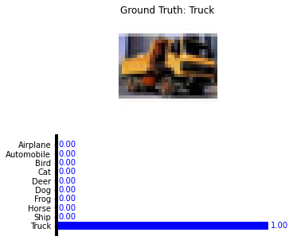

```python
# Choose a picture at random
idx = randint(0, test_size-1)
print(idx)
im, label = test_set[idx]
org_im = inverse_transform(im)

# Send to device, rescale, and view as a batch of 1
im = im.to(device)
im = im.view(1,3,32,32)

# Feed it to the net and display the confidence scores
scores = model(im)
probs = F.softmax(scores, dim=1)
show_prob_cifar(org_im, label, probs)
```

### Refining the Model

Although the vallina model has achieved fair classification results, the test error is still high remaining huge room for further improvement. There are lots of methods to refine your model, such as **modifying the network architecture** (e.g., making your network deeper), **optimizing the learning strategy** (e.g., optimizer, loss function), and **tuning the hyperparameters** (e.g., learning rate, training iterations), etc. Please try at least **TWO** different methods to improve your model's performance, and discuss why these changes can work. Design and conduct your own experiments using the coding cell below, and present your experimental results and analysis in a decent way (e.g., drawing some neat figures/tables can help to convey your thoughts effectively).

```
epoch= 0 	 time= 0.10 min 	 loss= 0.013 	 error= 60.00%
error rate on test set = 45.25%
epoch= 1 	 time= 0.22 min 	 loss= 0.009 	 error= 43.31%
error rate on test set = 33.19%
epoch= 2 	 time= 0.34 min 	 loss= 0.008 	 error= 35.99%
error rate on test set = 28.30%
epoch= 3 	 time= 0.45 min 	 loss= 0.007 	 error= 31.92%
error rate on test set = 27.71%
epoch= 4 	 time= 0.57 min 	 loss= 0.006 	 error= 28.36%
error rate on test set = 24.50%
epoch= 5 	 time= 0.69 min 	 loss= 0.006 	 error= 24.92%
error rate on test set = 22.74%
epoch= 6 	 time= 0.81 min 	 loss= 0.005 	 error= 22.18%
error rate on test set = 20.50%
epoch= 7 	 time= 0.92 min 	 loss= 0.005 	 error= 19.59%
error rate on test set = 18.28%
epoch= 8 	 time= 1.04 min 	 loss= 0.004 	 error= 17.52%
error rate on test set = 18.74%
epoch= 9 	 time= 1.16 min 	 loss= 0.004 	 error= 15.58%
error rate on test set = 17.73%
epoch= 10 	 time= 1.28 min 	 loss= 0.003 	 error= 13.57%
error rate on test set = 17.08%
epoch= 11 	 time= 1.39 min 	 loss= 0.003 	 error= 12.58%
error rate on test set = 17.18%
epoch= 12 	 time= 1.51 min 	 loss= 0.003 	 error= 11.21%
error rate on test set = 14.95%
epoch= 13 	 time= 1.63 min 	 loss= 0.002 	 error= 10.09%
error rate on test set = 15.52%
epoch= 14 	 time= 1.75 min 	 loss= 0.002 	 error= 8.50%
error rate on test set = 14.68%
epoch= 15 	 time= 1.86 min 	 loss= 0.002 	 error= 7.39%
error rate on test set = 14.90%
epoch= 16 	 time= 1.98 min 	 loss= 0.002 	 error= 6.65%
error rate on test set = 15.69%
epoch= 17 	 time= 2.10 min 	 loss= 0.001 	 error= 6.15%
error rate on test set = 15.89%
epoch= 18 	 time= 2.22 min 	 loss= 0.001 	 error= 5.17%
error rate on test set = 14.40%
epoch= 19 	 time= 2.34 min 	 loss= 0.001 	 error= 4.60%
error rate on test set = 16.86%
epoch= 20 	 time= 2.46 min 	 loss= 0.001 	 error= 4.39%
error rate on test set = 14.59%
epoch= 21 	 time= 2.58 min 	 loss= 0.001 	 error= 4.13%
error rate on test set = 15.54%
epoch= 22 	 time= 2.70 min 	 loss= 0.001 	 error= 3.74%
error rate on test set = 15.00%
epoch= 23 	 time= 2.82 min 	 loss= 0.001 	 error= 3.39%
error rate on test set = 15.69%
epoch= 24 	 time= 2.93 min 	 loss= 0.001 	 error= 3.13%
error rate on test set = 15.43%
```

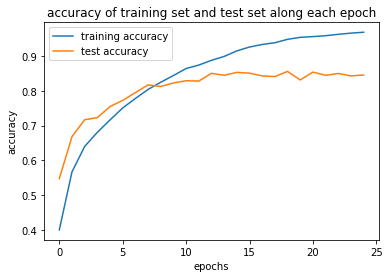

```python
##############################################################################
# TODO: Conduct experiments to refine your model (e.g., modify the backbone, #
# alter the learning strategy, and tuning the hyperparameters, etc.).        #
##############################################################################

# your code
torch.manual_seed(1)

# initialize a new model
nn = torch.nn
new_model = torch.nn.Sequential(
    # 3*32*32 -> 64*32*32
    nn.Conv2d(3, 64, 3, stride=1, padding='same'),
    nn.BatchNorm2d(64),
    nn.ReLU(),
    # 64*32*32 -> 64*32*32
    nn.Conv2d(64, 64, 3, stride=1, padding='same'),
    nn.BatchNorm2d(64),
    nn.ReLU(),
    # 64*32*32 -> 64*16*16
    nn.MaxPool2d(2, stride=2),

    # 64*16*16 -> 128*16*16
    nn.Conv2d(64, 128, 3, stride=1, padding='same'),
    nn.BatchNorm2d(128),
    nn.ReLU(),
    # 128*16*16 -> 128*16*16
    nn.Conv2d(128, 128, 3, stride=1, padding='same'),
    nn.BatchNorm2d(128),
    nn.ReLU(),
    # 128*16*16 -> 128*8*8
    nn.MaxPool2d(2, stride=2),

    # 128*8*8 -> 256*8*8
    nn.Conv2d(128, 256, 3, stride=1, padding='same'),
    nn.BatchNorm2d(256),
    nn.ReLU(),
    # 256*8*8 -> 256*8*8
    nn.Conv2d(256, 256, 3, stride=1, padding='same'),
    nn.BatchNorm2d(256),
    nn.ReLU(),
    # 256*8*8 -> 256*4*4
    nn.MaxPool2d(2, stride=2),

    # 256*4*4 ->  4096
    nn.Flatten(),
    # 4096 -> 128
    nn.Linear(256*4*4, 128),
    nn.ReLU(),
    nn.Dropout2d(p=0.5),

    # 128 -> 10
    nn.Linear(128, 10)
)

new_model.to(device)

# new hyperparameters
new_epochs = 25
new_learning_rate = 0.001

# Set up new optimizer
new_optimizer = optim.Adam(new_model.parameters(), lr=new_learning_rate, weight_decay=1e-4)

# start training
start = time.time()
new_model.train()

train_acc = []
test_acc = []

for epoch in range(new_epochs):
    # set the running quatities to zero at the beginning of the epoch
    running_loss = 0
    running_error = 0

    for data in train_loader:
        # Load inputs and labels and deploy to running device
        inputs, labels = data
        inputs, labels = inputs.to(device), labels.to(device)
        # print(labels[0:5])
        # Set the gradients to zeros
        new_optimizer.zero_grad()
        # Forward the batch data through the net
        outputs = new_model(inputs)
        # print(outputs[0:5])
        # Compute the average of the losses of the data points in the minibatch
        loss = criterion(outputs, labels)
        # Backward pass to compute gradients
        loss.backward()
        # Do one step of stochastic gradient descent
        new_optimizer.step()
        # Add the loss of this batch to the running loss
        running_loss = running_loss + loss.item()
        # Compute the error made on this batch and add it to the running error
        probs = F.softmax(outputs, dim=1)
        pred = torch.argmax(probs, dim=1)
        running_error = running_error + (pred != labels).int().sum()

    # Compute stats for the full training set
    total_loss = running_loss / train_size
    total_error = running_error / train_size
    elapsed = (time.time()-start) / 60

    print('epoch= {} \t time= {:.2f} min \t loss= {:.3f} \t error= {:.2f}%'.format(
        epoch, elapsed, total_loss, total_error * 100))

    train_acc.append(1 - total_error.cpu().data.numpy())

    new_model.eval()
    running_error = 0

    for data in test_loader:
        # Load inputs and labels and deploy to running device
        inputs, labels = data
        inputs, labels = inputs.to(device), labels.to(device)
        # Forward batch data through the net
        outputs = new_model(inputs)
        # Compute the error made on this batch and add it to the running error
        probs = F.softmax(outputs, dim=1)
        pred = torch.argmax(probs, dim=1)
        running_error = running_error + (pred != labels).int().sum()

    total_error = running_error / test_size
    print('error rate on test set = {:.2f}%'.format(total_error * 100))

    test_acc.append(1 - total_error.cpu().data.numpy())

    new_model.train()

# draw the accuracy along each epoch
plt.figure()
plt.plot(range(0, new_epochs), train_acc, label='training accuracy')
plt.plot(range(0, new_epochs), test_acc, label='test accuracy')
plt.title(f'accuracy of training set and test set along each epoch')
plt.xlabel('epochs')
plt.ylabel('accuracy')
plt.legend()
plt.show()
##############################################################################
#                             END OF YOUR CODE                               #
##############################################################################
```

**Write your observations and analysis in this Markdown cell:**

### 1. Make the network deeper (error rate: 21%-22%)

A deeper CNN is built based on the same original hyperparamers and learning strategy, which has 6 conv layers, 3 max pooling layers and one fully connected layer. The error rate has slightly reduced by around 2% (21%-22%). This might be because the extra conv layers can extract more features from the images which might help to classify. The accuracy is shown below.

[figure not shown]

### 2. Change the optimizer to Adam and learning rate (error rate: 20%-21%)

By using the Adam optimizer with learning rate as 0.001, the overall accuracy only improved about 1%. The adam optimizer can be more effective for computation and mermory with a sufficiently small learning rate (in this case it is 0.001) and can be used for big dataset. Besides, since the learning rate is smaller, it might be able to get to a better local minimum.

[figure not shown]

### 3. Regularization (error rate: 17%-20%)

As the above figures shown, the refined model has some overfitting issue after around 10 epochs. Therefore, it is necessary to do some regularization. After the fully connected layer, 50% dropout has been applied. The accuracy can be improved by between 1% and 3%, depending upon the initial weights.

[figure not shown]

Overall, how deep the network or complex the model is can have more effects on the final accuracy, but we also need to be careful about the overfitting problem.

### 4. Batch normalization (error rate: 14%-15%)

[figure not shown]

The batch normalization can keep the distribution of each conv layer output as similar as possible so that the model can learn the pattern faster (avoid the gradient being vanished). since the model is deeper than before, maintain the same distribution of each layer can help it to learn.

## Task 2: Model Interpretation

The model is doing well, eating images and predicting results; however, everything that happens inside is opaque and hard to explain. So, how can we interpret how CNN sees and understands when making a decision?

In this section, we are going to explore Grad-CAM, a visual explanation algorithm that generates heatmaps indicating where the network is "looking" in the forward pass.

#### Grad-CAM

Gradient-weighted Class Activation Mapping (Grad-CAM) [1], uses the gradients of any target concept, flowing into the final convolutional layer to produce a coarse localization map highlighting important regions in the image for predicting the concept. An overview of the workflow of Grad-CAM is shown below. Please read the paper [1], understand the algorithm, and implement `generate_cam`.

[figure not shown]

[1] [Selvaraju, Ramprasaath R., et al. "Grad-cam: Visual explanations from deep networks via gradient-based localization." ICCV 2017.](https://arxiv.org/abs/1610.02391)

```python
gradients = []  # A gloabl variable used to save the gradient


def generate_cam(model, input_image, target_layer='conv4', target_class=None):
    """
    A function to generate Grad-CAM of specific layer and class on an input image using given model.

    Inputs
    - model: A PyTorch model.
    - input_image: A PyTorch Tensor of shape (1, C, H, W).
    - target_layer: A String indicating the name of targeted convolutional layer being visualized (e.g., 'conv4').
                    By default, use the last conv layer of the model.
    - target_class: An Integer indicating the lable of targeted class being visualized (e.g., 1).
                    If None, use the predicted class as target class.

    Returns: A NumPy Array of shape (N, C, H, W) showing the intended heatmap.
    """

    ##############################################################################
    # TODO: Given an input image, generate its Grad-CAM on target conv layer     #
    # using the backward gradients from a specific class.                        #
    # 1. Forward the input image, when you also need to register the gradient    #
    # hook so as to get the gradient in backward pass (hint: register_hook).     #
    # 2. Backward pass with specified target class, and get gradients.           #
    # 3. Average each gradient, multiply with its conv output, and sum together. #
    ##############################################################################

    # your code
    # define hook functions
    output_features = []

    def get_feature_hook(_, __, output):
        # store the numpy type
        output_features.append(output.cpu().data.numpy().squeeze())

    grads = []

    def get_gradient_hook(_, __, grad):
        # store the numpy type
        grads.append(grad[0].cpu().data.numpy().squeeze())

    model.eval()

    # register hooks
    layer_instance = model._modules[target_layer]
    layer_instance.register_forward_hook(get_feature_hook)
    layer_instance.register_backward_hook(get_gradient_hook)

    # 1. forward
    scores = model(input_image)
    probs = F.softmax(scores, dim=1)
    pred_idx = np.argmax(probs.cpu().data.numpy())
    # print(f'predict class: {CIFAR_CLASSES[pred_idx]}')

    # get the one hot format of the target class
    if target_class != None:
        idx = target_class
    else:
        idx = pred_idx

    one_hot_output = F.one_hot(torch.tensor(idx), num_classes=scores.size()[1])
    # convert to float type
    one_hot_output = one_hot_output.float()
    one_hot_output.requires_grad = True
    # get the tensor(target class probability)
    target_val = torch.sum(one_hot_output.to(device) * scores)

    # 2. backward from the specific target class
    model.zero_grad()
    target_val.backward()

    # get the feature map and gradient of the corresponding layer
    features = output_features[0]
    grad = grads[0]

    # print(f'{target_layer} output feature size: {features.shape}')
    # print(f'{target_layer} output gradient size: {grad.shape}')

    # 3. average the grads, multiply to each feature and sum
    # get the weights for each feature (C, 1)
    weights = np.mean(grad, axis=(1, 2))

    # multiply to each feature and sum
    feature_c, feature_h, feature_w = features.shape
    # (1, C)*(C, H*W) = (1, H*W) -> (H, W)
    cam = np.dot(weights.T, features.reshape(
        (feature_c, feature_h*feature_w))).reshape((feature_h, feature_w))

    ##############################################################################
    #                             END OF YOUR CODE                               #
    ##############################################################################
    # Post processing
    cam = np.maximum(cam, 0)
    cam = (cam - np.min(cam)) / (np.max(cam) -
                                 np.min(cam))  # Normalize between 0-1
    cam = np.uint8(cam * 255)  # Scale between 0-255 to visualize
    cam = np.uint8(Image.fromarray(cam).resize((input_image.shape[2],
                                                input_image.shape[3]), Image.ANTIALIAS))

    return cam
```

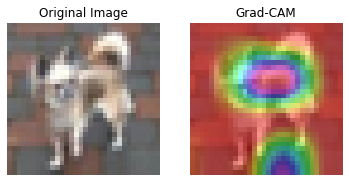

```python
idx = randint(0, test_size-1)
im, label = test_set[idx]
org_im = inverse_transform(im)

im = im.to(device)
im = im.view(1,3,32,32)

ax = plt.subplot(1, 2, 1)
ax.imshow(org_im)
ax.set_title('Original Image')
ax.set_axis_off()

cam = generate_cam(model, im)

heatmap, heatmap_on_image = apply_colormap_on_image(org_im, cam, 'hsv')

ax = plt.subplot(1, 2, 2)
ax.imshow(heatmap_on_image)
ax.set_title('Grad-CAM')
ax.set_axis_off()
```

### Performing Visual Explanation

Now you have successfully built a powerful tool (i.e., Grad-CAM) that can assist you to visualize and understand the CNN models. Try to make full use of `generate_cam` and design at least **TWO** experiments that can further explain how CNN sees and understands the images. For example, apply Grad-CAM on different layers and compare their differences. Please quantitatively show some evidence (e.g., plotting some examplar images clearly and elegantly) with necessary code snippets, write down your observations and briefly explain each.

```python
##############################################################################
# TODO: Write code snippets to present your experiments (hint: if you want   #
# to plot multiple images in one single figure, plt.subplot should help).    #
##############################################################################

# your code
# idx = randint(0, test_size-1)
# print(idx)
# 5544(wrong to deer) -> plane
# 8711 -> deer
def draw_cam(img_idx, target_class=None):
    im, label = test_set[img_idx]
    print(f'truth: {CIFAR_CLASSES[label]}')
    org_im = inverse_transform(im)

    im = im.to(device)
    im = im.view(1, 3, 32, 32)

    scores = model(im)
    probs = F.softmax(scores, dim=1)
    pred_idx = np.argmax(probs.cpu().data.numpy())
    print(f'predict class: {CIFAR_CLASSES[pred_idx]}')
    if (target_class == None):
        print(f'provided target class: {CIFAR_CLASSES[pred_idx]}')
    else:
        print(f'provided target class: {CIFAR_CLASSES[target_class]}')

    layers = ['conv1', 'conv2', 'conv3', 'conv4']

    plt.figure(figsize=(16, 8))
    col_num = 1+len(layers)
    ax = plt.subplot(1, col_num, 1)
    ax.imshow(org_im)
    ax.set_title('Original Image')
    ax.set_axis_off()

    # draw the grad_cam of each conv layer for this img
    for index, layer in enumerate(layers):
        cam = generate_cam(model, im, target_layer=layer,
                           target_class=target_class)

        _, heatmap_on_image = apply_colormap_on_image(org_im, cam, 'hsv')

        ax = plt.subplot(1, col_num, index+2)
        ax.imshow(heatmap_on_image)
        ax.set_title(f'Grad-CAM-{layer}')
        ax.set_axis_off()
```

```
===1. Difference between different layers for the same image===
truth: Deer
predict class: Deer
provided target class: Deer
```

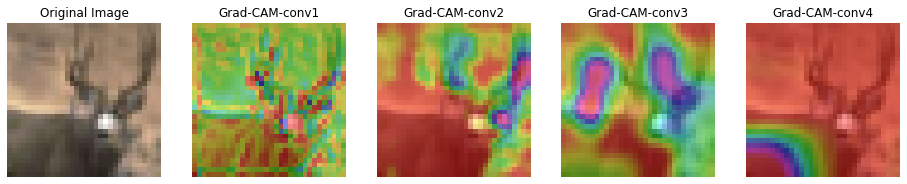

```python
print(f'===1. Difference between different layers for the same image===')
draw_cam(img_idx=8711, target_class=None)
```

```
===2. Wrong prediction cam===
truth: Airplane
predict class: Deer
provided target class: Deer
```

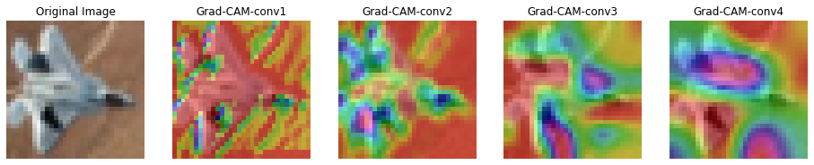

```python
print(f'===2. Wrong prediction cam===')
draw_cam(img_idx=5544, target_class=None)
```

```
===3. Wrong prediction cam with provided correct targer_class===
truth: Airplane
predict class: Deer
provided target class: Airplane
```

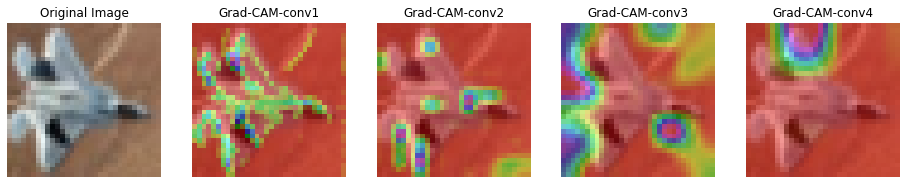

```python
print(f'===3. Wrong prediction cam with provided correct targer_class===')
# 0 is the airplane
draw_cam(img_idx=5544, target_class=0)
##############################################################################
#                             END OF YOUR CODE                               #
##############################################################################
```

**Write your observations and analysis in this Markdown cell:**

### 1. Different conv layers for the image

The grad cams of each conv layer for a deer image which is correctly predicted as a deer are shown in the below figure.

[figure not shown]

- conv1

The conv1 seems to focus more on the background environment of the deer.

- conv2

The conv2 layer focus more on the horns of the deer, which are more like the patrs of the deer itself.

- conv3

The conv3 is not that intuitive and explainable compared to the above two, but it might focus more on the overall position that a deer-type image should be.

- conv4 The conv4 might be focused on the smother part of the image or darker part of the image. In this case it is the body of the deer.

### 2. Cams for wrong prediction image

This part shows the cams of each conv layer of a air plane image whichi is wrongly predicted as a deer.

[figure not shown]

As the above figure shows, the focus points of each conv layer are similar to that of deer image. For example, the conv1 focuses on the background and boundary of the plane and the conv2 focuses on the plane itself, just like the horns of the deer. This might indicate that when the model classifies a image, firstly it will focuses more on the **background** in the conv1; then the focused point will be some **special shape** of the object itself; next it will be focused more on the **overall position** of the object and lastly the **smoother parts**.

### 3. Cams for providing a target class

This part shows the cams of the same plane image but with a provided target class which is the correct label.

[figure not shown]

As the above figure shows, when a target class (air plane) provided and using it to get the gradient, differnt cams can be obtained. This means a different target class for the same image has different cams, which might lead to different scores for differnet classes. The general focus points are similar to the previous air plane image but with different **"focused results"**. For example, in the conv1, the focused point might mainly be the background, but with this target class it focuses on the plane itself. This might be the one of the reasons why it is wrongly predicted.

## Task 3: Adversarial Attack

After going through some testing results in Task 1, you might think in most cases the model performs pretty well, predicting the correct classes with high confidence, and rarely making mistakes. However, the network is not as strong as you think. The network can be vulnerable and easily fooled by simply adding some very small distributions on input images. In this section, we are going to attack our previously trained model by generating adversarial images that visually look alike but crush the model without striking a blowing.

### Adversarial Examples

Adversarial examples are specialised inputs created with the purpose of confusing a neural network, resulting in the misclassification of a given input. These examples are usually generated by adding imperceptible non-random perturbations to the image, which are indistinguishable to human eye, but can cause the network to fail to identify the contents of the image. There are many kinds of such attack strategies, here we focus on the **Fast Gradient Sign Method (FGSM)** [2]. FGSM is a white box attack where the attacker has complete access to the model being attacked. The method uses the gradients of the loss with respect to the input image to create a new image that maximises the loss. Below shows a famous exmaple taken from the paper [2], where the classification of image showing "panda" is changed to "gibbon" after adding an imperceptibly small vector: $\text{sign}(\nabla_xJ(\theta, x, y))$.

[figure not shown]

Read the paper [2] for more details, and then implement the following function `generate_adv_image`, which generates "fooling images" of target class to attack your network.

[2] [Goodfellow, Ian J., Jonathon Shlens, and Christian Szegedy. "Explaining and harnessing adversarial examples." ICLR 2015.](https://arxiv.org/abs/1412.6572)

```python
def generate_adv_image(model, inputs, labels, targets=None, eps=0.07):
    """
    A function to generate adversarial examples.

    Inputs
    - model: A PyTorch model.
    - inputs: Input images, a PyTorch Tensor of shape (N, C, H, W).
    - labels: Ground truth labels of input images, a PyTorch Tensor of shape (N,).
    - targets: The target classes you want the model to misclassify, a PyTorch Tensor of shape (N,).

    Returns: The adversarial examples of given images.
    """

    ##############################################################################
    # TODO: Implement Fast Gradient Sign Method to generate an adversarial image #
    # that fools the model to predict incorrect class.                           #
    # 1. Get the gradients of the loss w.r.t to the input image.                 #
    # 2. Get the sign of the gradients to create the perturbation.               #
    # 3. Add the perturbation to the input image.                                #
    ##############################################################################

    # your code
    # 1. Get the gradients of the loss w.r.t to the input image.
    inputs.requires_grad = True
    scores = model(inputs)

    # get the loss
    # loss = F.nll_loss(scores, labels)
    if targets == None:
        # make the label index as a tensor and to the device
        if (torch.is_tensor(labels) == False):
            labels = torch.tensor(labels, dtype=torch.long).reshape((scores.size()[0])).to(device)
        loss = criterion(scores, labels)
    else:
        if (torch.is_tensor(targets) == False):
            targets = torch.tensor(targets, dtype=torch.long).reshape((scores.size()[0])).to(device)
        loss = criterion(scores, targets)

    model.zero_grad()
    loss.backward()

    # get the grad of the inputs
    grad = inputs.grad.data
    # print(f'gradients size of the loss w.r.t to the input image: {grad.shape}')

    # 2. Get the sign of the gradients to create the perturbation.
    sign_grad = grad.sign()

    if targets == None:
        adv_inputs = inputs + eps * sign_grad
    else:
        # if provided a target class, then remove the sign grad
        adv_inputs = inputs - eps * sign_grad

    ##############################################################################
    #                             END OF YOUR CODE                               #
    ##############################################################################

    return adv_inputs.detach()
```

### Attacking the Model

Randomly pick up some images from test set, and attack the model using adversarial examples generated by `generate_adv_image`.

```
Before attack:
```

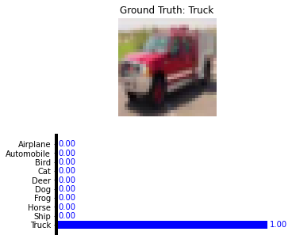

```
After attack:
```

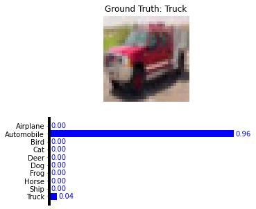

```python
idx = randint(0, len(test_set)-1)
im, label = test_set[idx]
org_im = inverse_transform(im)

im = im.to(device)
im = im.view(1,3,32,32)

print('Before attack:')
scores = model(im)
probs = F.softmax(scores, dim=1)
show_prob_cifar(org_im, label, probs)

adv_im = generate_adv_image(model, im, label)

print('After attack:')
scores = model(adv_im)
probs = F.softmax(scores, dim=1)
show_prob_cifar(inverse_transform(adv_im[0]), label, probs)
```

Run evaluation on the testing set to see how the model performs on the generated adversarial examples, and compare with results before attacks. Try different parameters (e.g., `targets`, `eps`), describe your observations with a brief explanation in the below cell.

```
error rate on test set = 24.00%
===error rate with different eps===
error rate when eps is 0.01: 33.34%
error rate when eps is 0.07: 66.20%
error rate when eps is 0.10: 69.56%
error rate when eps is 0.20: 73.30%
error rate when eps is 0.30: 74.78%
error rate when eps is 0.50: 76.20%


===error rate with different eps and target as 0===
error rate when eps is 0.01: 25.21%
error rate when eps is 0.07: 55.23%
error rate when eps is 0.10: 65.85%
error rate when eps is 0.20: 80.79%
error rate when eps is 0.30: 84.04%
error rate when eps is 0.50: 86.01%


===error rate with different eps and target as 5===
error rate when eps is 0.01: 26.72%
error rate when eps is 0.07: 56.50%
error rate when eps is 0.10: 67.88%
error rate when eps is 0.20: 83.51%
error rate when eps is 0.30: 86.81%
error rate when eps is 0.50: 88.25%


===error rate with different targets and eps as 0.2===
error rate when target is 0: 80.79%
error rate when target is 1: 82.81%
error rate when target is 2: 82.73%
error rate when target is 3: 83.65%
error rate when target is 4: 82.37%
error rate when target is 5: 83.51%
error rate when target is 6: 82.03%
error rate when target is 7: 82.97%
error rate when target is 8: 81.52%
error rate when target is 9: 82.07%
```

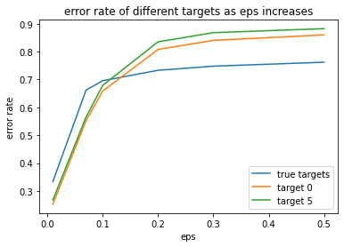

```python
##############################################################################
# TODO: Evaluate error rate on adversarial images generated from testing set #
# with different parameter settings.                                         #
##############################################################################

# your code
model.eval()
# get the error rate of the original testset for comparison
eval_on_test_set(model)

epss = [0.01, 0.07, 0.1, 0.2, 0.3, 0.5]
targets = [i for i in range(0, 10)]

def eval_on_adv_data(eps=0.07, target=None):
    adv_error = 0

    for data in test_loader:
        # Load inputs and labels and deploy to running device
        inputs, labels = data
        inputs, labels = inputs.to(device), labels.to(device)

        if target != None:
            adv_inputs = generate_adv_image(model, inputs, labels, eps=eps, targets=torch.full(labels.size(), fill_value=target).to(device)).to(device)
        else:
            adv_inputs = generate_adv_image(model, inputs, labels, eps=eps, targets=None).to(device)

        # Forward batch data through the net
        adv_output = model(adv_inputs)

        # Compute the error made on this batch and add it to the total error
        probs = F.softmax(adv_output, dim=1)
        pred = torch.argmax(probs, dim=1)
        adv_error = adv_error + (pred != labels).int().sum()

    adv_error = adv_error / test_size
    return adv_error

true_target_err = []
target_0_err = []
target_5_err = []

print(f'===error rate with different eps===')
for eps in epss:
    error = eval_on_adv_data(eps)
    true_target_err.append(error.cpu().data)
    print('error rate when eps is {:.2f}: {:.2f}%'.format(eps, error * 100))

print('\n')

print(f'===error rate with different eps and target as 0===')
for eps in epss:
    error = eval_on_adv_data(eps, target=0)
    target_0_err.append(error.cpu().data)
    print('error rate when eps is {:.2f}: {:.2f}%'.format(eps, error * 100))

print('\n')

print(f'===error rate with different eps and target as 5===')
for eps in epss:
    error = eval_on_adv_data(eps, target=5)
    target_5_err.append(error.cpu().data)
    print('error rate when eps is {:.2f}: {:.2f}%'.format(eps, error * 100))

print('\n')

print(f'===error rate with different targets and eps as 0.2===')
for target in targets:
    error = eval_on_adv_data(eps=0.2, target=target)
    print('error rate when target is {:d}: {:.2f}%'.format(target, error * 100))

# draw the error rate of different targets as eps increases
plt.figure()
plt.plot(epss, true_target_err, label='true targets')
plt.plot(epss, target_0_err, label='target 0')
plt.plot(epss, target_5_err, label='target 5')
plt.xlabel('eps')
plt.ylabel('error rate')
plt.title('error rate of different targets as eps increases')
plt.legend()
##############################################################################
#                             END OF YOUR CODE                               #
##############################################################################
```

**Write your observations and analysis in this Markdown cell:**

[figure not shown]

### 1. Error rate with different eps

By setting the eps from 0.01 to 0.5, it is obivious that the error rate rises as the eps increases, which is reasonable because the eps can determine how much effects that the sign_grads has on the original image.

### 2. Error rate with different eps when provided specific targets

As the above figure shows, when providing the target as 0 and 5, compared to the "true target", the error rate has reduced when the eps is small but increased when the eps is larger. The target 5 has higher error rate than that of the target 0.

- The might be because when using the "true target", we want to maximize the loss; while using other targets, we want to minimize the loss with respect to the provided target. When the eps is small, we might not be able to jump out the previous local minimum domain, but once the eps is bigger enough, we might be able to jump into another local minimum domain.
- Therefore, when the eps is small and we want to minimize the "provided target" loss, it is less likely to jump into anouther local minimum which will minimize the "provided target" loss, but the effects of maximizing the "true target" loss will be more. When the eps is bigger enough and we want to maximize the "true target" loss, it might not get to another local minimum of other target loss, but when wanting to minimize the "provided target" loss, it is more likely to get to another local minimum of the provided target loss.

### 3. Error rate with different targets when eps is 0.2

The error rates of differnt provided targets are from 80% to 83% when the eps is 0.2. They are all higher than the error rate of the "true target". Therefore, it might indicate that we can have a heavier attack with a provided target and sufficiently larger eps. However, when the eps is too larger (smaller than 1), the attacked image will be more obivious.